# Imputing missing data on the Ecological parameters data set

Floret Justine

2024-10-11

The first method, with the missMDA package, is based on a regularized iterative PCA algorithm. It is imputing the missing data first with the mean of each variable, then with PCA to iterate until convergence, avoiding over fitting issues (J. Josse, F. Husson). The second method is based on a random forest algorithm, training it on observed data to impute the missing ones (Stekhoven, Bühlmann).

To test which method infers better the missing values, a sub data set with no missing data was used to randomly and non randomly replace observed values by NA. Both inferring methods were used to impute the missing data on it. Then the imputed data sets were compared to the observed one with Pearson Chi square test, mean squared error, a F test and correlation coefficient.

```r
library(readr)
library("plyr") # Needed for Ellenberg value
library(dplyr)
library(tidyr)
library(reshape2) # melt function
library(forcats) # reorganize in geom boxplot
library(data.table)
library(wakefield) # randomly replace value by na
library(stringr) #  remove strings in a column
library(lmerTest) #glht
library(lmerTest) #glht
library(lsmeans) #pairwise comparison
library(emmeans)
library(multcomp)  #glht
library(multcompView)  #glht
library(rstatix) # manova levene test
library(nnet) # glm with factor
library(GGally) #ppair plot
library(ggplot2)
library(viridis)
library(svglite) # save in svg format
library(shiny)
library(FactoInvestigate)
library(FactoMineR)
library(Factoshiny)
library(missMDA)
library(factoextra)
library("corrplot")
library("Hmisc")
library(missForest)# impute missing value
library(bigstep)
library(randomForest)
```

```r
colors <- c("#6a176e", "#bc3754", "#f37819", "#f8cd37")
```

### Preparing the data set.

```r
Ecological_parameters <- read_csv("/home/justine/sciebo/2_Ecological_parameters/2_assays/Ecological_parameters_0.csv")
Ecological_parameters$Site_ID <- as.factor(Ecological_parameters$Site_ID)
Ecological_parameters$Area <- as.factor(Ecological_parameters$Area)
Ecological_parameters$Localization_ID <- as.factor(Ecological_parameters$Localization_ID)
Ecological_parameters$Type <- as.factor(Ecological_parameters$Type)
Ecological_parameters$Destroyed <- as.factor(Ecological_parameters$Destroyed)
Ecological_parameters$Outliers_soil <- as.factor(Ecological_parameters$Outliers_soil)
Ecological_parameters$Sowing_1st <- as.factor(Ecological_parameters$Sowing_1st)
Ecological_parameters$Sowing_2nd <- as.factor(Ecological_parameters$Sowing_2nd)
```

The sites destroyed before the measurement of the ecological parameters, in April 2022, are removed as well as the site definitively destroyed in April 2023. The measurements were done in the site sown in September 2021, the others sites are also removed from the analysis.

```r
complete_data <- Ecological_parameters %>% filter(Sowing_1st =="09/2021" ) %>% filter(Sowing_2nd =="no")
complete_data <- complete_data %>% filter(Destroyed !="02/2022" ) %>% filter(Destroyed !="04/2023")
complete_data <- complete_data[,c(4,22:151)]
complete_data$Type <- as.factor(complete_data$Type )
```

# I. PCA imputation missing data

This method is based on a regularized iterative PCA algorithm. It is imputing the missing data first with the mean of each variable, then with PCA to iterate until convergence, avoiding over fitting issues (J. Josse, et al, 2010).

First create a data set with no missing data.

```r
data_noNA <- na.omit(complete_data)
```

## 1. PCA imputing random NA values

Replace randomly values of the data set with no missing data by NA.

```r
data_randomNA <- data_noNA %>% r_na(cols = 2:131, prob = 0.08)
```

Then impute the NA with missMDA package.

```r
nPCs <- estim_ncpPCA(data_randomNA[,2:131])
data_randomNA_impute_PCA <- missMDA::imputePCA(data_randomNA, quanti.sup=c(130),quali.sup=c(1), ncp=nPCs$ncp)$completeObs
```

### Compare the imputed data with the observed ones from the data set with no missing value.

Different statistical test are realized to compare the data set with no missing data (observed data) with the data set with imputed data, to infer if the method is imputing correctly.

```r
# Get the common column names
common_columns <- intersect(names(data_noNA[,2:131]), names(data_randomNA_impute_PCA[,2:131]))

# Initialize lists to store correlations and p-values
correlation_results <- list()
pvalue_results <- list()
```

- Correlation:  
  Looking at the correlation coefficient between the observed datas and the imputed ones.

```r
for (col in common_columns) {
  result <- rcorr(as.matrix(data_noNA[[col]]), as.matrix(data_randomNA_impute_PCA[[col]]))
  correlation_results[[col]] <- result$r[1, 2]  # Extract the correlation coefficient
  pvalue_results[[col]] <- result$P[1, 2]      # Extract the p-value
}
```

Convert lists to named vectors for easier readability.

```r
correlations <- unlist(correlation_results)
pvalues <- unlist(pvalue_results)
comparison_obs_imputed <- data.frame("Correlations_imputePCA" = correlations, "pvalues_imputePCA" = pvalues)
```

- Chi square test:  
  Pearson’s Chi-squared Test is testing if there is a significant association between the categories of the two variables.  
  H0: the row and the column variables of the contingency table are independent.  
  H1: row and column variables are dependent, the observed value and the imputed ones are dependent.

```r
comparison_obs_imputed$Chitest_imputePCA <- rep(99, 130)
for (col in common_columns) {
  results_chitest <- chisq.test(data_noNA[[col]], data_randomNA_impute_PCA[[col]], correct = FALSE)
  comparison_obs_imputed[col,3]  <- results_chitest[["p.value"]]
}
```

- Mean squared error:  
  MSE is predicting accuracy of a model. It is calculated as: MSE = (1/n) * Σ(actual – prediction)²  
  The lower the value for MSE, the more accurately a model is able to predict values.

```r
comparison_obs_imputed$MSE_imputePCA <- rep(99, 130)
for (col in common_columns) {
  comparison_obs_imputed[col,4] <- mean((data_noNA[[col]] - data_randomNA_impute_PCA[[col]])^2)
}
```

- F test:  
  F-test is used to assess whether the variances of two populations (A and B) are equal, here the observed data and the imputed ones.  
  H0: σ1² = σ2² (the population variances are equal).  
  /! sensitive to the normality of the sample distribution.

```r
comparison_obs_imputed$Ftest_imputePCA <- rep(99, 130)
for (col in common_columns) {
  F1<- var.test(data_noNA[[col]], data_randomNA_impute_PCA[[col]])
  comparison_obs_imputed[col,5] <- F1[["p.value"]]
}
```

## 2. PCA imputing nonrandom NA values

Replace non randomly values of the data set with no missing data by NA.

```r
data_NorandomNA <- data_noNA

# Add NA in Temperature (mean, min, max, DD) Humidity variables
data_NorandomNA <- data_NorandomNA %>%
 mutate(across(3:67, ~ if_else(Type == "pavement", na_if(., .), .)))

# Add NA in N%, C% and Ions in random rows
data_NorandomNA <- data_NorandomNA %>%
 mutate(across(90:96, ~ if_else(row_number() %in% 44:77, na_if(., .), .)))

# Add NA in soil parameters for tree bed
data_NorandomNA <- data_NorandomNA %>%
 mutate(across(69:84, ~ if_else(Type == "Tree bed", na_if(., .), .)))

# Add a little bit of NA randomly in every column
data_NorandomNA <- data_NorandomNA %>% r_na(cols = 2:131, prob = 0.04)
```

Then impute the NA with missMDA package.

```r
data_NorandomNA_impute_PCA <- missMDA::imputePCA(data_NorandomNA, quanti.sup=c(130),quali.sup=c(1))$completeObs
```

### Compare the imputed data with the observed ones from the data set with no missing value.

- Correlation:  
  Looking at the correlation coefficient between the observed datas and the imputed ones.

```r
correlation_results <- list()
pvalue_results <- list()

# Compute the correlation and p-values for each pair of columns with the same name using rcorr
for (col in common_columns) {
  result <- rcorr(as.matrix(data_noNA[[col]]), as.matrix(data_NorandomNA_impute_PCA[[col]]))
  correlation_results[[col]] <- result$r[1, 2]  # Extract the correlation coefficient
  pvalue_results[[col]] <- result$P[1, 2]      # Extract the p-value
}
```

Convert lists to named vectors for easier readability

```r
correlations <- unlist(correlation_results)
pvalues <- unlist(pvalue_results)
comparison_obs_NorandomNA <- data.frame("Correlations_imputePCA" = correlations, "pvalues_imputePCA" = pvalues)
```

- Chi square test:  
  Pearson’s Chi-squared Test is testing if there is a significant association between the categories of the two variables.  
  H0: the row and the column variables of the contingency table are independent.  
  H1: row and column variables are dependent, the observed value and the imputed ones are dependent.

```r
comparison_obs_NorandomNA$Chitest_imputePCA <- rep(99, 130)
for (col in common_columns) {
  results_chitest <- chisq.test(data_noNA[[col]], data_NorandomNA_impute_PCA[[col]], correct = FALSE)
  comparison_obs_NorandomNA[col,3]  <- results_chitest[["p.value"]]
}
```

- Mean squared error  
  MSE is predicting accuracy of a model. It is calculated as: MSE = (1/n) * Σ(actual – prediction)²  
  The lower the value for MSE, the more accurately a model is able to predict values.

```r
comparison_obs_NorandomNA$MSE_imputePCA <- rep(99, 130)
for (col in common_columns) {
  comparison_obs_NorandomNA[col,4] <- mean((data_noNA[[col]] - data_NorandomNA_impute_PCA[[col]])^2)
}
```

- F test  
  F-test is used to assess whether the variances of two populations (A and B) are equal, here the observed data and the imputed ones.  
  H0: σ1² = σ2² (the population variances are equal).  
  /! sensitive to the normality of the sample distribution.

```r
comparison_obs_NorandomNA$Ftest_imputePCA <- rep(99, 130)
for (col in common_columns) {
  F1<- var.test(data_noNA[[col]], data_NorandomNA_impute_PCA[[col]])
  comparison_obs_NorandomNA[col,5] <- F1[["p.value"]]
}
```

# II. Random Forest imputation missing data

This method is based on a random forest algorithm, training it on observed data to impute the missing ones (Stekhoven and Bühlmann,2011).  
Information about the random forest package to impute data:  
- [Petrazzini et al, 2021](https://link.springer.com/article/10.1186/s13040-021-00274-7#Abs1)  
- [Using the missForest package](https://rpubs.com/FelipeSantos/na_missforest)

## 1. missForest test imputing ramdom NA values

Use the same data (data_randomNA) than for the PCA method

```r
data_randomNA_impute_MF <- missForest(data_randomNA[,2:131])$ximp #remove factor column
data_randomNA_impute_MF$Type <- data_randomNA$Type
```

### Compare the imputed data with the observed ones from the data set with no missing value.

- Correlation:  
  Looking at the correlation coefficient between the observed datas and the imputed ones.

```r
for (col in common_columns) {
  result <- rcorr(as.matrix(data_noNA[[col]]), as.matrix(data_randomNA_impute_MF[[col]]))
  correlation_results[[col]] <- result$r[1, 2]  # Extract the correlation coefficient
  pvalue_results[[col]] <- result$P[1, 2]      # Extract the p-value
}
correlations <- unlist(correlation_results)
pvalues <- unlist(pvalue_results)
comparison_obs_imputed$Correlations_imputeMF <- as.numeric(correlations)
comparison_obs_imputed$pvalues_imputeMF <- as.numeric(pvalues)
```

- Chi square test:  
  Pearson’s Chi-squared Test is testing if there is a significant association between the categories of the two variables.  
  H0: the row and the column variables of the contingency table are independent.  
  H1: row and column variables are dependent, the observed value and the imputed ones are dependent.

```r
comparison_obs_imputed$Chitest_imputeMF <- rep(99, 130)
for (col in common_columns) {
  results_chitest <- chisq.test(data_noNA[[col]], data_randomNA_impute_MF[[col]], correct = FALSE)
  comparison_obs_imputed[col,8]  <- results_chitest[["p.value"]]}
```

- Mean squared error MSE is predicting accuracy of a model. It is calculated as: MSE = (1/n) * Σ(actual – prediction)²  
  The lower the value for MSE, the more accurately a model is able to predict values.

```r
comparison_obs_imputed$MSE_imputeMF <- rep(99, 130)
for (col in common_columns) {
  comparison_obs_imputed[col,9] <- mean((data_noNA[[col]] - data_randomNA_impute_MF[[col]])^2)
}
```

- F test  
  F-test is used to assess whether the variances of two populations (A and B) are equal, here the observed data and the imputed ones.  
  H0: σ1² = σ2² (the population variances are equal).  
  /! sensitive to the normality of the sample distribution.

```r
comparison_obs_imputed$Ftest_imputeMF <- rep(99, 130)
for (col in common_columns) {
  F1<- var.test(data_noNA[[col]], data_randomNA_impute_MF[[col]])
  comparison_obs_imputed[col,10] <- F1[["p.value"]]
}
```

Transform the table in data frame.

```r
comparison_obs_imputed <- tibble::rownames_to_column(comparison_obs_imputed, "Parameters")
```

## 2. missForest imputing nonrandom NA values

Use same data (data_NorandomNA) than for the PCA method

```r
data_NorandomNA_impute_MF <- missForest(data_NorandomNA[,2:131])$ximp
data_NorandomNA_impute_MF$Type <- data_NorandomNA$Type
```

### Compare the imputed data with the observed ones from the data set with no missing value.

- Correlation:  
  Looking at the correlation coefficient between the observed datas and the imputed ones.

```r
for (col in common_columns) {
  result <- rcorr(as.matrix(data_noNA[[col]]), as.matrix(data_NorandomNA_impute_MF[[col]]))
  correlation_results[[col]] <- result$r[1, 2]  # Extract the correlation coefficient
  pvalue_results[[col]] <- result$P[1, 2]      # Extract the p-value
}
correlations <- unlist(correlation_results)
pvalues <- unlist(pvalue_results)
comparison_obs_NorandomNA$Correlations_imputeMF <- as.numeric(correlations)
comparison_obs_NorandomNA$pvalues_imputeMF <- as.numeric(pvalues)
```

- Chi square test:  
  Pearson’s Chi-squared Test is testing if there is a significant association between the categories of the two variables.  
  H0: the row and the column variables of the contingency table are independent.  
  H1: row and column variables are dependent, the observed value and the imputed ones are dependent.

```r
comparison_obs_NorandomNA$Chitest_imputeMF <- rep(99, 130)
for (col in common_columns) {
  results_chitest <- chisq.test(data_noNA[[col]], data_NorandomNA_impute_MF[[col]], correct = FALSE)
  comparison_obs_NorandomNA[col,8]  <- results_chitest[["p.value"]]}
```

- Mean squared error  
  MSE is predicting accuracy of a model. It is calculated as: MSE = (1/n) * Σ(actual – prediction)²  
  The lower the value for MSE, the more accurately a model is able to predict values.

```r
comparison_obs_NorandomNA$MSE_imputeMF <- rep(99, 130)
for (col in common_columns) {
  comparison_obs_NorandomNA[col,9] <- mean((data_noNA[[col]] - data_NorandomNA_impute_MF[[col]])^2)
}
```

- F test  
  F-test is used to assess whether the variances of two populations (A and B) are equal, here the observed data and the imputed ones.  
  H0: σ1² = σ2² (the population variances are equal).  
  /! sensitive to the normality of the sample distribution.

```r
comparison_obs_NorandomNA$Ftest_imputeMF <- rep(99, 130)
for (col in common_columns) {
  F1<- var.test(data_noNA[[col]], data_NorandomNA_impute_MF[[col]])
  comparison_obs_NorandomNA[col,10] <- F1[["p.value"]]
}
```

Transform the table in data frame.

```r
comparison_obs_NorandomNA <- tibble::rownames_to_column(comparison_obs_NorandomNA, "Parameters")
```

# III. Comparison of the PCA and random forest method to impute the missing values

## 1. Imputation of random NA

### Correlation

```r
correlation <- comparison_obs_imputed %>%
  rowwise() %>%
  mutate( mymean = mean(c(Correlations_imputePCA,Correlations_imputeMF) )) %>%
  arrange(mymean) %>%
  mutate(Parameters=factor(Parameters))
```

Correlation coefficient between the observed data and the imputed ones.

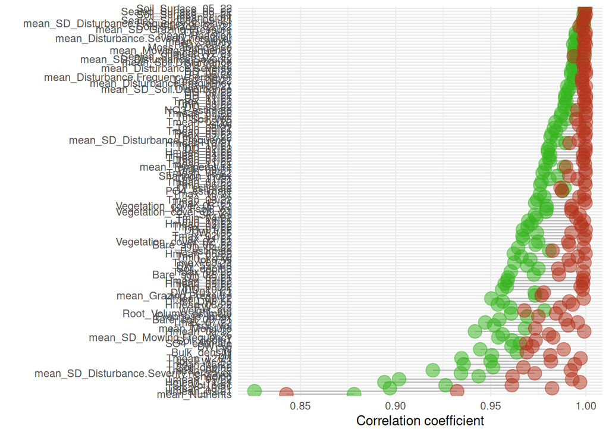

```r
ggplot(correlation) +
  geom_segment( aes(x=Parameters, xend=Parameters, y=Correlations_imputePCA, yend=Correlations_imputeMF), color="grey") +
  geom_point( aes(x=Parameters, y=Correlations_imputePCA), color=rgb(0.2,0.7,0.1,0.5), size=5 ) +
  geom_point( aes(x=Parameters, y=Correlations_imputeMF), color=rgb(0.7,0.2,0.1,0.5), size=5 ) +
  coord_flip()+
  theme_minimal() +
  xlab("") +
  ylab("Correlation coefficient")
```

### Mean square error

MSE is predicting accuracy of a model. It is calculated as: MSE = (1/n) * Σ(actual – prediction)²  
The lower the value for MSE, the more accurately a model is able to predict values.

```r
correlation <- correlation %>%
  rowwise() %>%
  mutate( mymean = mean(c(MSE_imputePCA,MSE_imputeMF) )) %>%
  arrange(mymean) %>%
  mutate(Parameters=factor(Parameters))
```

Ecological parameters with the highest MSE value (removed F- estimation values to high), the worth imputed variables.

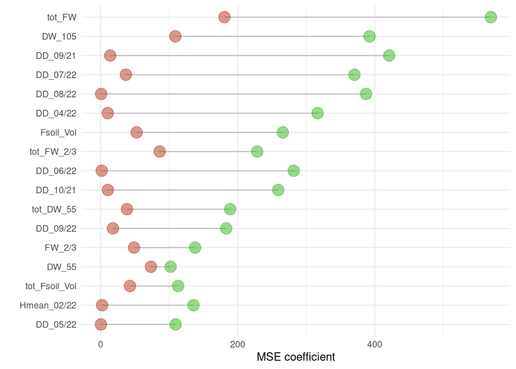

```r
correlation %>% filter(mymean > 50 & mymean < 500) %>%
  ggplot() +
  geom_segment( aes(x=Parameters, xend=Parameters, y=MSE_imputePCA, yend=MSE_imputeMF), color="grey") +
  geom_point( aes(x=Parameters, y=MSE_imputePCA), color=rgb(0.2,0.7,0.1,0.5), size=5 ) +
  geom_point( aes(x=Parameters, y=MSE_imputeMF), color=rgb(0.7,0.2,0.1,0.5), size=5 ) +
  coord_flip()+
  theme_minimal() +
  xlab("") +
  ylab("MSE coefficient")
```

### F test

F-test is used to assess whether the variances of two populations (A and B) are equal, here the observed data and the imputed ones.  
H0: σ1² = σ2² (the population variances are equal).  
/! sensitive to the normality of the sample distribution.

```r
correlation <- correlation %>%
  rowwise() %>%
  mutate( mymean = mean(c(Ftest_imputePCA,Ftest_imputeMF) )) %>%
  arrange(mymean) %>%
  mutate(Parameters=factor(Parameters))
```

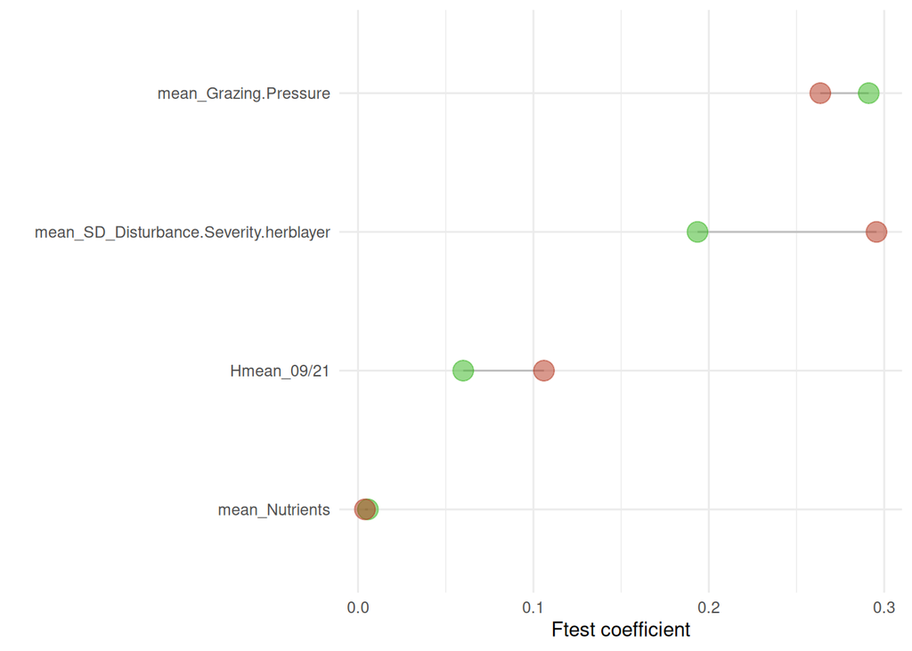

```r
correlation  %>% filter(mymean < 0.3) %>%
  ggplot() +
  geom_segment( aes(x=Parameters, xend=Parameters, y=Ftest_imputePCA, yend=Ftest_imputeMF), color="grey") +
  geom_point( aes(x=Parameters, y=Ftest_imputePCA), color=rgb(0.2,0.7,0.1,0.5), size=5 ) +
  geom_point( aes(x=Parameters, y=Ftest_imputeMF), color=rgb(0.7,0.2,0.1,0.5), size=5 ) +
  coord_flip()+
  theme_minimal() +
  xlab("") +
  ylab("Ftest coefficient")
```

### Chitest

Pearson’s Chi-squared Test is testing if there is a significant association between the categories of the two variables.  
H0: the row and the column variables of the contingency table are independent.

Ecological parameters with a non significant p-value at Chi-sqaure test

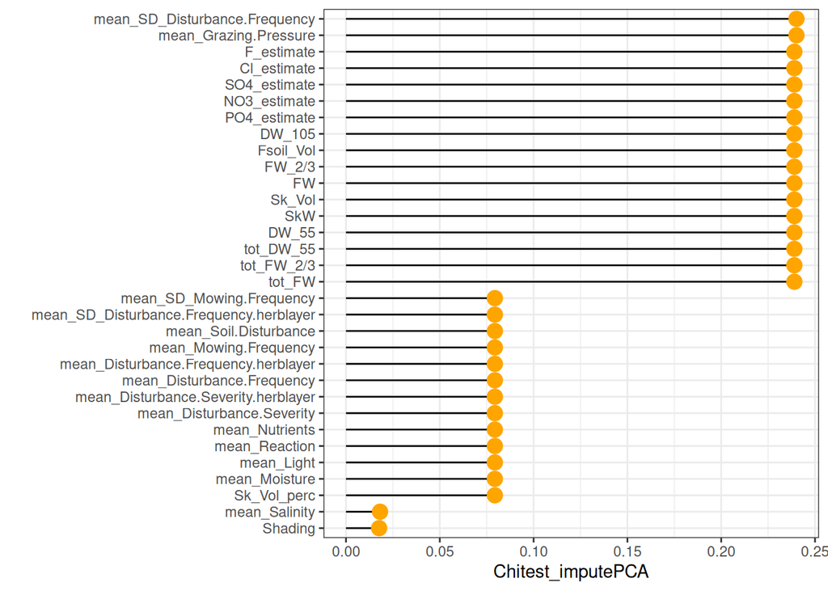

```r
comparison_obs_imputed %>% filter(Chitest_imputePCA >= 0.01) %>%
  arrange(Chitest_imputePCA) %>%    # First sort by val. This sort the dataframe but NOT the factor levels
  mutate(Parameters=factor(Parameters, levels=Parameters)) %>%   # This trick update the factor levels
  ggplot( aes(x=Parameters, y=Chitest_imputePCA)) +
  geom_segment( aes(xend=Parameters, yend=0)) +
  geom_point( size=4, color="orange") +
  coord_flip() +
  theme_bw() +
  xlab("")
```

## 2.Imputation of non random NA

### Correlation

```r
correlation <- comparison_obs_NorandomNA %>%
  rowwise() %>%
  mutate( mymean = mean(c(Correlations_imputePCA,Correlations_imputeMF) )) %>%
  arrange(mymean) %>%
  mutate(Parameters=factor(Parameters))
```

Correlation coefficient between the observed data and the imputed ones.

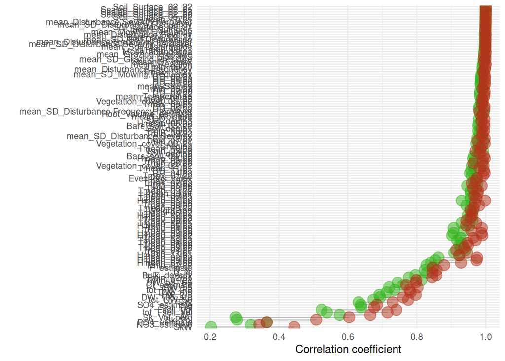

```r
ggplot(correlation) +
  geom_segment( aes(x=Parameters, xend=Parameters, y=Correlations_imputePCA, yend=Correlations_imputeMF), color="grey") +
  geom_point( aes(x=Parameters, y=Correlations_imputePCA), color=rgb(0.2,0.7,0.1,0.5), size=5 ) +
  geom_point( aes(x=Parameters, y=Correlations_imputeMF), color=rgb(0.7,0.2,0.1,0.5), size=5 ) +
  coord_flip()+
  theme_minimal() +
  xlab("") +
  ylab("Correlation coefficient")
```

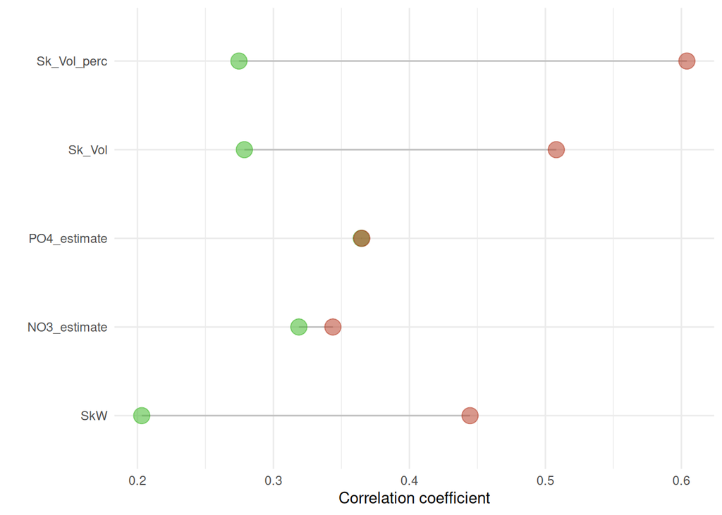

```r
correlation %>% filter(mymean < 0.50) %>%
  ggplot() +
  geom_segment( aes(x=Parameters, xend=Parameters, y=Correlations_imputePCA, yend=Correlations_imputeMF), color="grey") +
  geom_point( aes(x=Parameters, y=Correlations_imputePCA), color=rgb(0.2,0.7,0.1,0.5), size=5 ) +
  geom_point( aes(x=Parameters, y=Correlations_imputeMF), color=rgb(0.7,0.2,0.1,0.5), size=5 ) +
  coord_flip()+
  theme_minimal() +
  xlab("") +
  ylab("Correlation coefficient")
```

### Mean square error

MSE is predicting accuracy of a model. It is calculated as: MSE = (1/n) * Σ(actual – prediction)²  
The lower the value for MSE, the more accurately a model is able to predict values.

```r
correlation <- correlation %>%
  rowwise() %>%
  mutate( mymean = mean(c(MSE_imputePCA,MSE_imputeMF) )) %>%
  arrange(mymean) %>%
  mutate(Parameters=factor(Parameters))
```

Ecological parameters with the highest MSE value (removed F- estimation values to high), the worth imputed variables.

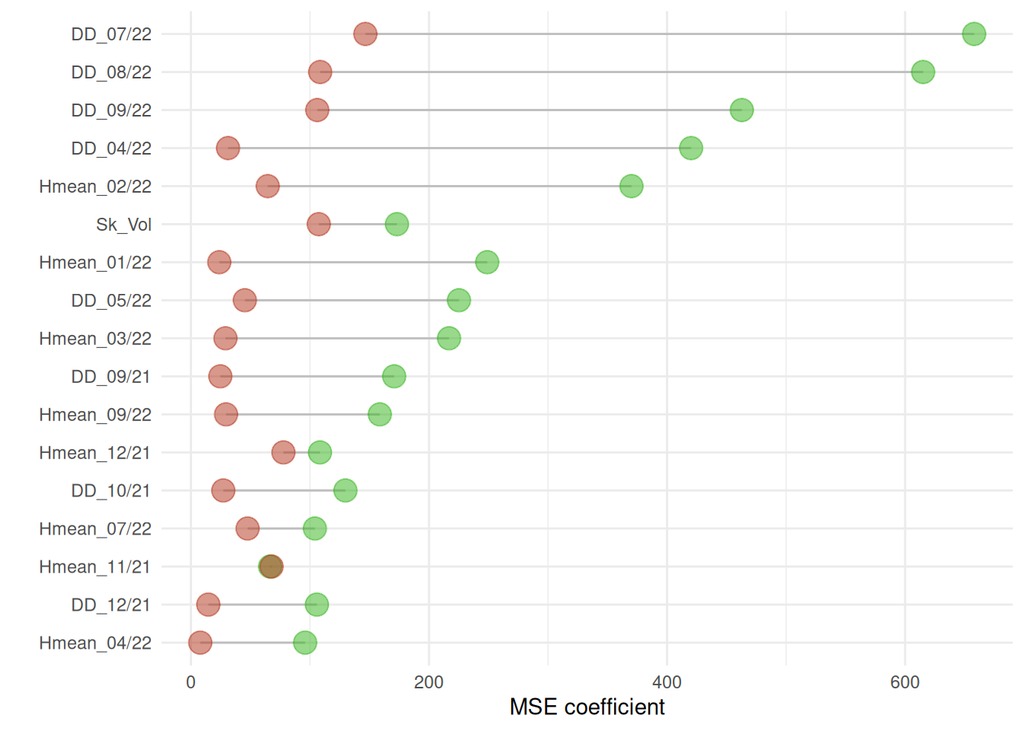

```r
correlation %>% filter(mymean > 50 & mymean < 500) %>%
  ggplot() +
  geom_segment( aes(x=Parameters, xend=Parameters, y=MSE_imputePCA, yend=MSE_imputeMF), color="grey") +
  geom_point( aes(x=Parameters, y=MSE_imputePCA), color=rgb(0.2,0.7,0.1,0.5), size=5 ) +
  geom_point( aes(x=Parameters, y=MSE_imputeMF), color=rgb(0.7,0.2,0.1,0.5), size=5 ) +
  coord_flip()+
  theme_minimal() +
  xlab("") +
  ylab("MSE coefficient")
```

```r
#ggsave("Higher MSE coefficient nonrandomNA.svg", plot =  last_plot(),dpi = 300, bg = "white", scale = 2 )
```

### F test

F-test is used to assess whether the variances of two populations (A and B) are equal, here the observed data and the imputed ones.  
H0: σ1² = σ2² (the population variances are equal).  
/! sensitive to the normality of the sample distribution.

```r
correlation <- correlation %>%
  rowwise() %>%
  mutate( mymean = mean(c(Ftest_imputePCA,Ftest_imputeMF) )) %>%
  arrange(mymean) %>%
  mutate(Parameters=factor(Parameters))
```

Ecological parameters with variance significantly different between the observed and imputed datas.

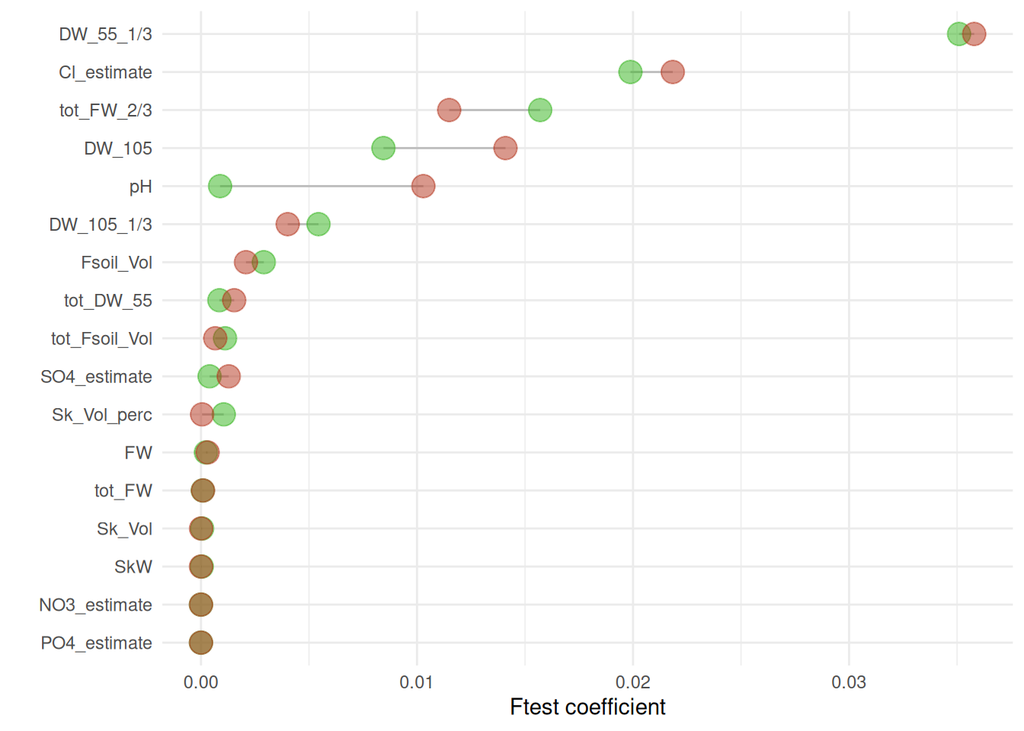

```r
correlation  %>% filter(mymean < 0.05) %>%
  ggplot() +
  geom_segment( aes(x=Parameters, xend=Parameters, y=Ftest_imputePCA, yend=Ftest_imputeMF), color="grey") +
  geom_point( aes(x=Parameters, y=Ftest_imputePCA), color=rgb(0.2,0.7,0.1,0.5), size=5 ) +
  geom_point( aes(x=Parameters, y=Ftest_imputeMF), color=rgb(0.7,0.2,0.1,0.5), size=5 ) +
  coord_flip()+
  theme_minimal() +
  xlab("") +
  ylab("Ftest coefficient")
```

```r
#ggsave("significant Ftest coefficient nonrandomNA.svg", plot =  last_plot(),dpi = 300, bg = "white", scale = 2 )
```

### Chitest

Pearson’s Chi-squared Test is testing if there is a significant association between the categories of the two variables.  
H0: the row and the column variables of the contingency table are independent.

Ecological parameters with a non significant p-value at Chi-sqaure test

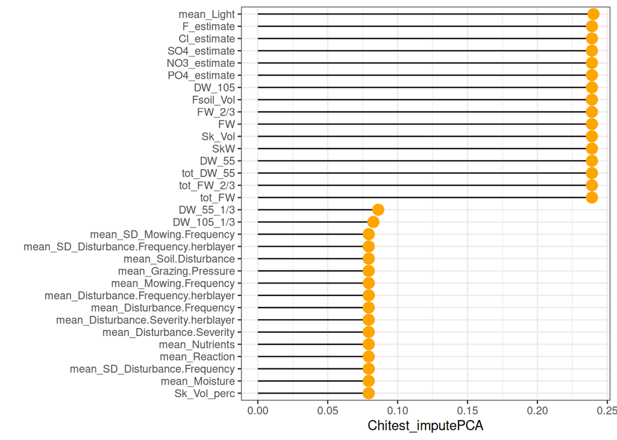

```r
comparison_obs_NorandomNA   %>% filter(Chitest_imputePCA >= 0.05)  %>%
  arrange(Chitest_imputePCA) %>%    # First sort by val. This sort the dataframe but NOT the factor levels
  mutate(Parameters=factor(Parameters, levels=Parameters)) %>%   # This trick update the factor levels
  ggplot( aes(x=Parameters, y=Chitest_imputePCA)) +
  geom_segment( aes(xend=Parameters, yend=0)) +
  geom_point( size=4, color="orange") +
  coord_flip() +
  theme_bw() +
  xlab("")
```

```r
#ggsave("significant Chitest pvalue nonrandomNA.svg", plot =  last_plot(),dpi = 300, bg = "white", scale = 2 )
```

```r
correlation <- correlation %>%
  rowwise() %>%
  mutate( mymean = mean(c(Chitest_imputePCA,Chitest_imputeMF) )) %>%
  arrange(mymean) %>%
  mutate(Parameters=factor(Parameters))
```

## 3. Distribution of non significant parameters

Selection of the ecological parameters with a non significant Chi test.

```r
parameters_nosig <- comparison_obs_NorandomNA %>% filter(Chitest_imputePCA >0.01 )
```

Keeping interesting parameters (removing Ellenberg)

```r
parameters_nosig <- parameters_nosig[1:22,]
```

Creating a data set with both imputed value and the observed data

```r
data_tmp1 <- data_noNA %>% select(Type, all_of(parameters_nosig$Parameters))
data_tmp2 <- data_NorandomNA_impute_PCA %>% select(Type, all_of(parameters_nosig$Parameters))
colnames(data_tmp2)[-1] <- paste0(colnames(data_tmp2)[-1], "_PCA")
data_tmp3 <- data_NorandomNA_impute_MF %>% select(Type, all_of(parameters_nosig$Parameters))
colnames(data_tmp3)[-1] <- paste0(colnames(data_tmp3)[-1], "_MF")
data_impute_nosig <- cbind(data_tmp1, data_tmp2[,2:23], data_tmp3[,2:23])
data_impute_nosig_melt <- reshape2::melt(data_impute_nosig)
colnames(data_impute_nosig_melt) <- c("Type", "Parameters", "Value")
data_impute_nosig_melt$Method <- c(rep("aObserved", 2156), rep("PCA", 2156),rep("MF", 2156))
data_impute_nosig_melt$Parameters <-str_remove_all(data_impute_nosig_melt$Parameters, "_PCA")
data_impute_nosig_melt$Parameters <-str_remove_all(data_impute_nosig_melt$Parameters, "_MF")
```

Distribution of ecological parameters, observed data and the imputed ones based on the method of imputation.

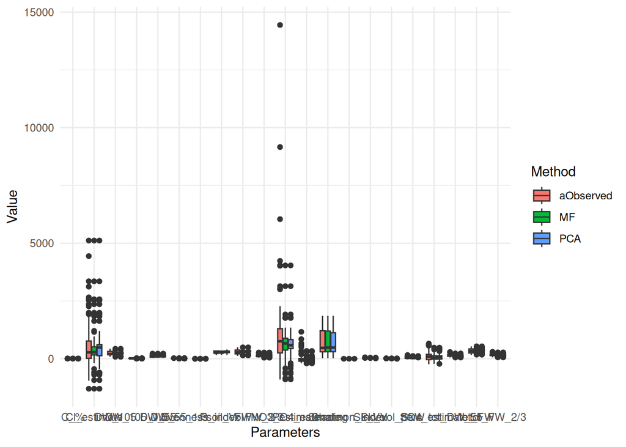

```r
data_impute_nosig_melt  %>% dplyr::filter(Parameters != "F_estimate") %>%
  ggplot( aes(x = Parameters ,y=Value, fill = Method)) + geom_boxplot() +
  theme_minimal()
```

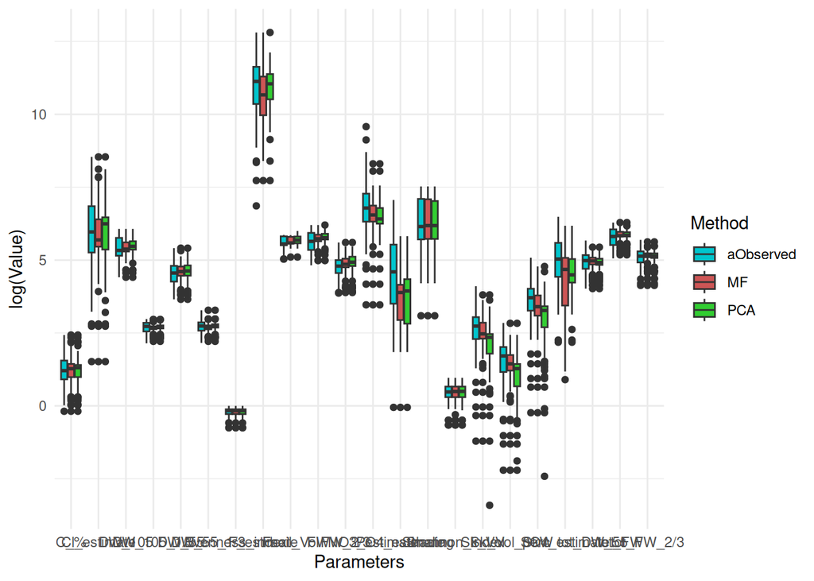

```r
ggplot(data_impute_nosig_melt, aes(x = Parameters ,y= log(Value), fill = Method)) + geom_boxplot() +
  theme_minimal() + scale_fill_manual(values = c("#00C5CD", "#CD5555", "#32CD32"))
```

Linear model to test which method impute the best the data

```r
data_impute_nosig_melt$Method <- factor(data_impute_nosig_melt$Method)
model <- lm(Value ~ Method/Parameters, data = data_impute_nosig_melt)
summary(model)
```

```
##
## Call:
## lm(formula = Value ~ Method/Parameters, data = data_impute_nosig_melt)
##
## Residuals:
##     Min      1Q  Median      3Q     Max
## -115584     -27       0      12  317636
##
## Coefficients:
##                                            Estimate Std. Error t value Pr(>|t|)
## (Intercept)                                  3.9080  1367.7205   0.003    0.998
## MethodMF                                    -0.1432  1934.2489   0.000    1.000
## MethodPCA                                   -0.1984  1934.2489   0.000    1.000
## MethodaObserved:ParametersCl_estimate      553.8148  1934.2489   0.286    0.775
## MethodMF:ParametersCl_estimate             466.6262  1934.2489   0.241    0.809
## MethodPCA:ParametersCl_estimate            528.9985  1934.2489   0.273    0.784
## MethodaObserved:ParametersDW_105           227.7877  1934.2489   0.118    0.906
## MethodMF:ParametersDW_105                  234.2665  1934.2489   0.121    0.904
## MethodPCA:ParametersDW_105                 241.9845  1934.2489   0.125    0.900
## MethodaObserved:ParametersDW_105_1/3        11.0779  1934.2489   0.006    0.995
## MethodMF:ParametersDW_105_1/3               10.8228  1934.2489   0.006    0.996
## MethodPCA:ParametersDW_105_1/3              11.1074  1934.2489   0.006    0.995
## MethodaObserved:ParametersDW_55             95.6733  1934.2489   0.049    0.961
## MethodMF:ParametersDW_55                    98.5301  1934.2489   0.051    0.959
## MethodPCA:ParametersDW_55                  100.9514  1934.2489   0.052    0.958
## MethodaObserved:ParametersDW_55_1/3         11.4007  1934.2489   0.006    0.995
## MethodMF:ParametersDW_55_1/3                11.1055  1934.2489   0.006    0.995
## MethodPCA:ParametersDW_55_1/3               11.6276  1934.2489   0.006    0.995
## MethodaObserved:ParametersEvenness_index    -3.0937  1934.2489  -0.002    0.999
## MethodMF:ParametersEvenness_index           -2.9490  1934.2489  -0.002    0.999
## MethodPCA:ParametersEvenness_index          -2.8954  1934.2489  -0.001    0.999
## MethodaObserved:ParametersF_estimate     54390.7689  1934.2489  28.120   <2e-16
## MethodMF:ParametersF_estimate            47540.1858  1934.2489  24.578   <2e-16
## MethodPCA:ParametersF_estimate           56944.3296  1934.2489  29.440   <2e-16
## MethodaObserved:ParametersFsoil_Vol        276.4170  1934.2489   0.143    0.886
## MethodMF:ParametersFsoil_Vol               281.1531  1934.2489   0.145    0.884
## MethodPCA:ParametersFsoil_Vol              293.8841  1934.2489   0.152    0.879
## MethodaObserved:ParametersFW               285.8153  1934.2489   0.148    0.883
## MethodMF:ParametersFW                      312.3585  1934.2489   0.161    0.872
## MethodPCA:ParametersFW                     321.5979  1934.2489   0.166    0.868
```

[output cut: 94 more lines]

```
## MethodaObserved:Parameterstot_DW_55
## MethodMF:Parameterstot_DW_55
## MethodPCA:Parameterstot_DW_55
## MethodaObserved:Parameterstot_FW
## MethodMF:Parameterstot_FW
## MethodPCA:Parameterstot_FW
## MethodaObserved:Parameterstot_FW_2/3
## MethodMF:Parameterstot_FW_2/3
## MethodPCA:Parameterstot_FW_2/3
## ---
## Signif. codes:  0 '***' 0.001 '**' 0.01 '*' 0.05 '.' 0.1 ' ' 1
##
## Residual standard error: 13540 on 6402 degrees of freedom
## Multiple R-squared:  0.4013, Adjusted R-squared:  0.3952
## F-statistic: 66.02 on 65 and 6402 DF,  p-value: < 2.2e-16
```

```r
car::Anova(model)
```

```
## Anova Table (Type II tests)
##
## Response: Value
##                       Sum Sq   Df F value Pr(>F)
## Method            2.2021e+08    2  0.6006 0.5485
## Method:Parameters 7.8649e+11   63 68.0973 <2e-16 ***
## Residuals         1.1736e+12 6402
## ---
## Signif. codes:  0 '***' 0.001 '**' 0.01 '*' 0.05 '.' 0.1 ' ' 1
```

Pairwise comparison

```r
model <- lmer(Value ~ Parameters +Method + (Method|Parameters), data = data_impute_nosig_melt)
summary(model)
```

```
## Linear mixed model fit by REML. t-tests use Satterthwaite's method [
## lmerModLmerTest]
## Formula: Value ~ Parameters + Method + (Method | Parameters)
##    Data: data_impute_nosig_melt
##
## REML criterion at convergence: 141017
##
## Scaled residuals:
##     Min      1Q  Median      3Q     Max
## -8.3056 -0.0111 -0.0054  0.0160 23.1660
##
## Random effects:
##  Groups     Name        Variance  Std.Dev. Corr
##  Parameters (Intercept) 191686369 13845.1
##             MethodMF       278009   527.3   0.16
##             MethodPCA       39485   198.7  -0.16 -1.00
##  Residual               182727224 13517.7
## Number of obs: 6468, groups:  Parameters, 22
##
## Fixed effects:
##                            Estimate Std. Error         df t value Pr(>|t|)
## (Intercept)              -9.332e+01  1.386e+04  2.031e-07  -0.007    1.000
## ParametersCl_estimate     5.468e+02  1.960e+04  2.030e-07   0.028    1.000
## ParametersDW_105          2.364e+02  1.960e+04  2.030e-07   0.012    1.000
## ParametersDW_105_1/3      1.112e+01  1.960e+04  2.030e-07   0.001    1.000
## ParametersDW_55           9.884e+01  1.960e+04  2.030e-07   0.005    1.000
## ParametersDW_55_1/3       1.158e+01  1.960e+04  2.030e-07   0.001    1.000
## ParametersEvenness_index -2.979e+00  1.960e+04  2.030e-07   0.000    1.000
## ParametersF_estimate      5.681e+04  1.960e+04  2.030e-07   2.898    1.000
## ParametersFsoil_Vol       2.874e+02  1.960e+04  2.030e-07   0.015    1.000
## ParametersFW              3.065e+02  1.960e+04  2.030e-07   0.016    1.000
## ParametersFW_2/3          1.289e+02  1.960e+04  2.030e-07   0.007    1.000
## ParametersNO3_estimate    8.326e+02  1.960e+04  2.030e-07   0.042    1.000
## ParametersPO4_estimate   -4.184e+01  1.960e+04  2.030e-07  -0.002    1.000
## ParametersShading         6.874e+02  1.960e+04  2.030e-07   0.035    1.000
## ParametersShannon_index  -2.192e+00  1.960e+04  2.030e-07   0.000    1.000
## ParametersSk_Vol          9.538e+00  1.960e+04  2.030e-07   0.000    1.000
## ParametersSk_Vol_perc     7.014e-01  1.960e+04  2.030e-07   0.000    1.000
## ParametersSkW             3.067e+01  1.960e+04  2.030e-07   0.002    1.000
## ParametersSO4_estimate    7.556e+01  1.960e+04  2.030e-07   0.004    1.000
## Parameterstot_DW_55       1.363e+02  1.960e+04  2.030e-07   0.007    1.000
## Parameterstot_FW          3.427e+02  1.960e+04  2.030e-07   0.017    1.000
## Parameterstot_FW_2/3      1.641e+02  1.960e+04  2.030e-07   0.008    1.000
## MethodMF                 -3.368e+02  4.268e+02  6.069e+01  -0.789    0.433
## MethodPCA                 9.262e+01  4.139e+02  7.372e+02   0.224    0.823
```

```
## optimizer (nloptwrap) convergence code: 0 (OK)
## boundary (singular) fit: see help('isSingular')
```

```r
car::Anova(model)
```

```
## Analysis of Deviance Table (Type II Wald chisquare tests)
##
## Response: Value
##              Chisq Df Pr(>Chisq)
## Parameters 15.9360 21     0.7732
## Method      1.0477  2     0.5922
```

Use emmeans to compare the Method for each Parameters

```r
emm <- emmeans(model, ~ Method | Parameters, pbkrtest.limit = 9408)
pairwise_comparisons <- contrast(emm, method = "pairwise")
summary(pairwise_comparisons)
```

```
## Parameters = C_%:
##  contrast        estimate  SE df t.ratio p.value
##  aObserved - MF     336.8 427 21   0.789  0.7136
##  aObserved - PCA    -92.6 414 21  -0.224  0.9728
##  MF - PCA          -429.4 440 21  -0.976  0.5994
##
## Parameters = Cl_estimate:
##  contrast        estimate  SE df t.ratio p.value
##  aObserved - MF     336.8 427 21   0.789  0.7136
##  aObserved - PCA    -92.6 414 21  -0.224  0.9728
##  MF - PCA          -429.4 440 21  -0.976  0.5994
##
## Parameters = DW_105:
##  contrast        estimate  SE df t.ratio p.value
##  aObserved - MF     336.8 427 21   0.789  0.7136
##  aObserved - PCA    -92.6 414 21  -0.224  0.9728
##  MF - PCA          -429.4 440 21  -0.976  0.5994
##
## Parameters = DW_105_1/3:
##  contrast        estimate  SE df t.ratio p.value
##  aObserved - MF     336.8 427 21   0.789  0.7136
##  aObserved - PCA    -92.6 414 21  -0.224  0.9728
##  MF - PCA          -429.4 440 21  -0.976  0.5994
##
## Parameters = DW_55:
##  contrast        estimate  SE df t.ratio p.value
##  aObserved - MF     336.8 427 21   0.789  0.7136
##  aObserved - PCA    -92.6 414 21  -0.224  0.9728
##  MF - PCA          -429.4 440 21  -0.976  0.5994
##
## Parameters = DW_55_1/3:
##  contrast        estimate  SE df t.ratio p.value
##  aObserved - MF     336.8 427 21   0.789  0.7136
##  aObserved - PCA    -92.6 414 21  -0.224  0.9728
##  MF - PCA          -429.4 440 21  -0.976  0.5994
##
## Parameters = Evenness_index:
##  contrast        estimate  SE df t.ratio p.value
##  aObserved - MF     336.8 427 21   0.789  0.7136
##  aObserved - PCA    -92.6 414 21  -0.224  0.9728
```

[output cut: 79 more lines]

```
##
## Parameters = tot_FW:
##  contrast        estimate  SE df t.ratio p.value
##  aObserved - MF     336.8 427 21   0.789  0.7136
##  aObserved - PCA    -92.6 414 21  -0.224  0.9728
##  MF - PCA          -429.4 440 21  -0.976  0.5994
##
## Parameters = tot_FW_2/3:
##  contrast        estimate  SE df t.ratio p.value
##  aObserved - MF     336.8 427 21   0.789  0.7136
##  aObserved - PCA    -92.6 414 21  -0.224  0.9728
##  MF - PCA          -429.4 440 21  -0.976  0.5994
##
## Degrees-of-freedom method: kenward-roger
## P value adjustment: tukey method for comparing a family of 3 estimates
```

# IV Imputing the data set

```r
data_to_impute <- Ecological_parameters %>% filter(Sowing_1st =="09/2021" ) %>% filter(Sowing_2nd =="no")
data_to_impute <- data_to_impute %>% filter(Destroyed !="02/2022" ) %>% filter(Destroyed !="04/2023")

data_to_impute$Site_ID <- as.factor(data_to_impute$Site_ID)
data_to_impute$Type <- as.factor(data_to_impute$Type)
data_to_impute <- data_to_impute[,c(1,22:151)]
data_to_impute <- as.data.frame(data_to_impute)
data_to_impute <- data_to_impute %>%
  mutate(across(where(is.character), as.numeric))  # Convert character columns to numeric if needed

dim(data_to_impute)
```

```
## [1] 368 131
```

## 1. PCA imputation

```r
data_PCA_impute <- missMDA::imputePCA(data_to_impute, quanti.sup=130,quali.sup=1, ncp=2)$completeObs
```

## 2. MF imputation

```r
data_MF_impute <- missForest(data_to_impute[,2:131])$ximp #remove factor column
data_MF_impute <- cbind("Site_ID"=data_to_impute$Site_ID, data_MF_impute)
```

## 3. Mean of the imputations

Ensure both data frames have the same dimensions

```r
if (all(dim(data_PCA_impute) == dim(data_MF_impute))) {
  # Compute the mean
  data_imputed <- (data_PCA_impute[,2:131] + data_MF_impute[,2:131]) / 2
} else {
  stop("Data frames must have the same dimensions")
}
```

Add the phenology again to the data set

```r
data_to_impute <- Ecological_parameters %>% filter(Sowing_1st =="09/2021" ) %>% filter(Sowing_2nd =="no")
data_to_impute <- data_to_impute %>% filter(Destroyed !="02/2022" ) %>% filter(Destroyed !="04/2023")

data_imputed <-cbind(data_to_impute[,1:21],data_imputed)
```

J. Josse, F. Husson et J. Pagès (2009) Gestion des données manquantes en Analyse en Composantes Principales. Journal de la SFdS. 150 (2), pp. 28-51. Josse, J., Husson, F. (2010). Multiple Imputation in PCA.

Stekhoven, D. J., & Bühlmann, P. (2011). MissForest—non-parametric missing value imputation for mixed-type data. Bioinformatics, 28(1), 112-118.

Petrazzini, B.O., Naya, H., Lopez-Bello, F. et al. Evaluation of different approaches for missing data imputation on features associated to genomic data. BioData Mining 14, 44 (2021). https://doi.org/10.1186/s13040-021-00274-7